# Supplementary Material for the Statistical Analysis of the Honours Thesis

Trung Ho Huynh

2026-01-27

The following section presents the statistical analysis conducted for the Honours thesis of Trung Ho Huynh. The experiment was designed as a controlled study isolating two primary independent variables: grinding duration, and the contact area of the active stone. The dependent variable in this study is surface morphology of the granite passive stone, characterised by mean surface slope (MSI) derived from terrain-based spatial analysis.

The primary aim of this statistical procedure is to test the following hypotheses:

H₁: Increased grinding duration is associated with greater granite surface morphological modification, expressed as systematic changes in surface slope.

H₂: Smaller contact areas will produce higher rates of surface modification (expressed as greater changes in slope and/or surface roughness per unit time) than larger contact areas (after Dunbreli et al., 2014).

```r
### Libraries required for this analysis.
library(terra)
library(tmap)
library(tidyverse)
library(lme4)
library(lmerTest)
library(purrr)
library(lattice)
library(ggthemes)
```

The following code demonstrates the custom script written by the author for this analysis.

```r
# ------------------------------
# write functions: compute mean slope time-series for one run, and slope visulisation.
# ------------------------------
get_slope_ts <- function(dem_dir, run_id) {

  keep_names <- c("original.tif","20m.tif","40m.tif","60m.tif",
                  "80m.tif","100m.tif","120m.tif")
  dem_files  <- file.path(dem_dir, keep_names)
  stopifnot(all(file.exists(dem_files)))

  # parse time from filenames
  base <- tools::file_path_sans_ext(basename(dem_files))
  time_min <- ifelse(base == "original", 0,
                     as.numeric(sub("m$", "", base)))
  stopifnot(!any(is.na(time_min)))

  # order by time
  ord <- order(time_min)
  dem_files <- dem_files[ord]
  time_min  <- time_min[ord]

  # read DEMs and compute slope
  dem_list <- lapply(dem_files, rast)
  dem_list <- lapply(dem_list, function(r) {
    names(r) <- "elevation"; r
  })

  slope_list <- lapply(dem_list, function(dem_r) {
    terrain(dem_r, v = "slope",
            unit = "degrees", neighbors = 8)
  })

  # mean slope per time step
  slope_mean <- vapply(
    slope_list,
    function(s) global(s, "mean", na.rm = TRUE)[1, 1],
    numeric(1)
  )

  data.frame(
    run        = run_id,
    grinding_duration   = time_min,
    slope_mean = slope_mean
  )
}
```

```r
# Visualisation: slope at ORIGINAL and at 120 minute after each experiment
# ------------------------------
plot_slope_0_120 <- function(dem_dir, run_id,
                             hs_angle = 45, hs_dir = 315,
                             slope_alpha = 0.65) {

  tmap_options(max.raster = 1e8)

  keep_names <- c("original.tif","20m.tif","40m.tif","60m.tif",
                  "80m.tif","100m.tif","120m.tif")
  dem_files  <- file.path(dem_dir, keep_names)
  stopifnot(all(file.exists(dem_files)))

  base <- tools::file_path_sans_ext(basename(dem_files))
  time_min <- ifelse(base == "original", 0, as.numeric(sub("m.*$", "", base)))
  stopifnot(!any(is.na(time_min)))

  f0   <- dem_files[time_min == 0][1]
  f120 <- dem_files[time_min == 120][1]

  dem0   <- rast(f0)
  dem120 <- rast(f120)

  # ---- SLOPE for colouring (degrees) ----
  slope0_deg   <- terrain(dem0,   v = "slope", unit = "degrees", neighbors = 8)
  slope120_deg <- terrain(dem120, v = "slope", unit = "degrees", neighbors = 8)

  # ---- SLOPE/ASPECT for hillshade MUST be radians ----
  slope0_rad   <- terrain(dem0,   v = "slope",  unit = "radians", neighbors = 8)
  aspect0_rad  <- terrain(dem0,   v = "aspect", unit = "radians", neighbors = 8)
  slope120_rad <- terrain(dem120, v = "slope",  unit = "radians", neighbors = 8)
  aspect120_rad<- terrain(dem120, v = "aspect", unit = "radians", neighbors = 8)

  hs0   <- shade(slope0_rad,   aspect0_rad,   angle = hs_angle, direction = hs_dir)
  hs120 <- shade(slope120_rad, aspect120_rad, angle = hs_angle, direction = hs_dir)

  # Optional: boost hillshade contrast a bit (often helps a lot)
  hs0   <- clamp((hs0   - 0.4) * 1.4 + 0.4, 0, 1)
  hs120 <- clamp((hs120 - 0.4) * 1.4 + 0.4, 0, 1)

  # ---- Paper-like breaks (more resolution at low slopes) ----
  breaks <- c(0, 2, 5, 8, 12, 16, 20, 25, 30, 35, 45, 60, 90)

  # ---- Paper-like palette (green -> yellow -> orange -> brown -> dark) ----
  slope_cols <- c(
    "#1a9850", "#66bd63", "#a6d96a", "#d9ef8b",
    "#fee08b", "#fdae61", "#f46d43", "#d73027",
    "#8c510a", "#3b1f0b"
  )

  make_map <- function(hs, slope_deg, title_txt) {
    tm_shape(hs) +
      tm_raster(
        col.scale  = tm_scale_continuous(values = "grey10"),
        col.legend = tm_legend(show = FALSE)
      ) +
      tm_shape(slope_deg) +
      tm_raster(
        col.scale  = tm_scale_intervals(values = slope_cols, breaks = breaks, style = "fixed"),
        col_alpha  = slope_alpha,
        col.legend = tm_legend(title = "Slope (deg)")
      ) +
      tm_layout(frame = FALSE, legend.position = c("right", "bottom")) +
      tm_title(title_txt)
  }

  map_slope0   <- make_map(hs0,   slope0_deg,   paste0("Slope - ", run_id, " (0 min)"))
  map_slope120 <- make_map(hs120, slope120_deg, paste0("Slope - ", run_id, " (120 min)"))

  print(tmap_arrange(map_slope0, map_slope120))
}
```

Next, the raster DEM files were imported from the local directory. Using the custom function defined above, *the get_slope_ts()* function automatically computes the mean surface slope index (MSI) of each granite surface at every measurement point, from the original surface through to the surface after two hours of grinding. As a result, a data frame was generated containing 56 rows of observations, representing mean slope measurements for all eight granite samples recorded at 20-minute intervals.

```r
# ------------------------------
### Phrase 1: data input and graphic visualisation of the surface change
# ------------------------------

# Input all runs
ts_run1 <- get_slope_ts("./DEMs/GRA-1-LO/", "GRA-1-LO")
ts_run2 <- get_slope_ts("./DEMs/GRA-2-LO/", "GRA-2-LO")
ts_run3 <- get_slope_ts("./DEMs/GRA-3-LO/", "GRA-3-LO")
ts_run4 <- get_slope_ts("./DEMs/GRA-4-LO/", "GRA-4-LO")
ts_run5 <- get_slope_ts("./DEMs/GRA-5-LO/", "GRA-5-LO")
ts_run6 <- get_slope_ts("./DEMs/GRA-6-LO/", "GRA-6-LO")
ts_run7 <- get_slope_ts("./DEMs/GRA-7-LO/", "GRA-7-LO")
ts_run8 <- get_slope_ts("./DEMs/GRA-8-LO/", "GRA-8-LO")
ts_all <- rbind(ts_run1, ts_run2, ts_run3, ts_run4, ts_run5,ts_run6,ts_run7, ts_run8)
```

Table 1: example mean slope measurements of granite passive stone GRA-1-LO throughout the Experiment

| run | grinding_duration | slope_mean |
| --- | --- | --- |
| GRA-1-LO | 0 | 16.38390 |
| GRA-1-LO | 20 | 16.37398 |
| GRA-1-LO | 40 | 16.18403 |
| GRA-1-LO | 60 | 16.21984 |
| GRA-1-LO | 80 | 16.09669 |
| GRA-1-LO | 100 | 16.08646 |

We can now visualise the surface modification of each granite grinding slab by comparing its original surface with the surfaces resulting after two hours of grinding. This is achieved by calculating surface slope using the *`terrain()`* function from the *`terra`* package. The rate of change is computed using a moving window that calculates the difference between each central cell and its eight neighbouring cells.

[output not shown]

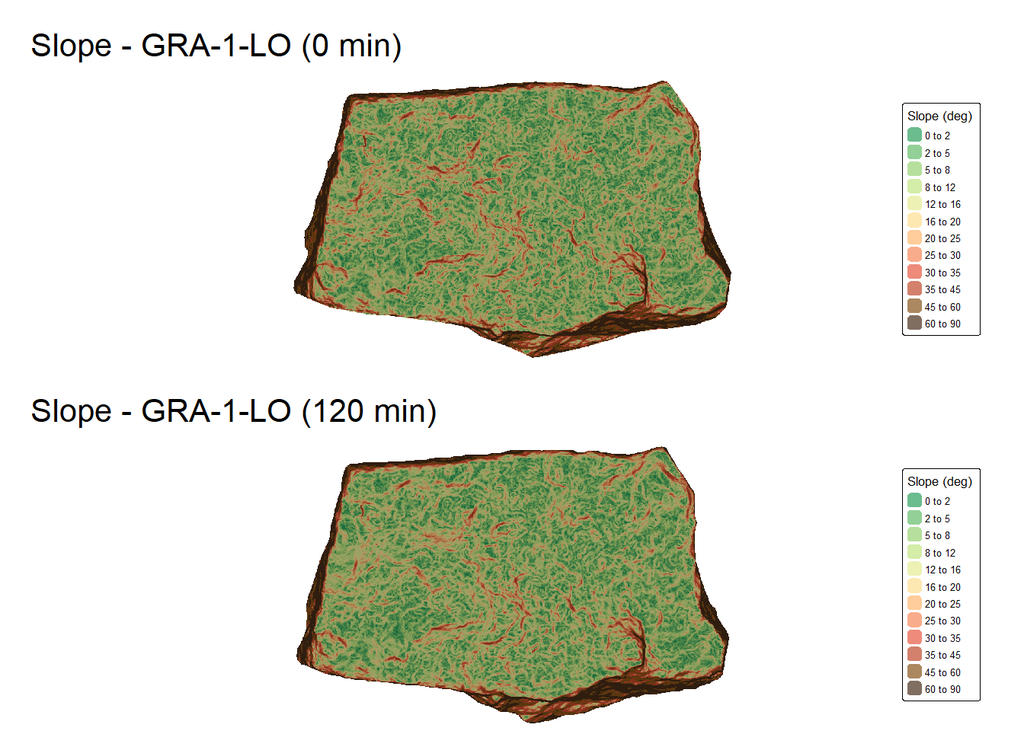

```r
# plot figures using tmap to visulise the change in the surface
plot_slope_0_120("./DEMs/GRA-1-LO/", "GRA-1-LO")
```

[output not shown]

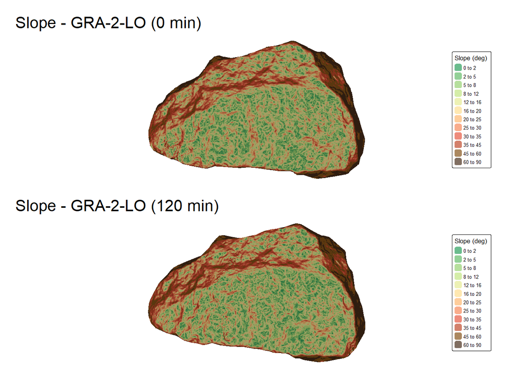

```r
plot_slope_0_120("./DEMs/GRA-2-LO/", "GRA-2-LO")
```

```
## [v3->v4] `tmap_options()`: use raster.max_cells instead of max.raster
```

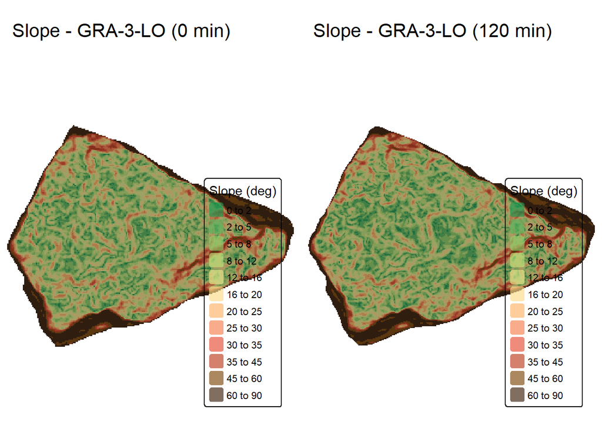

```r
plot_slope_0_120("./DEMs/GRA-3-LO/", "GRA-3-LO")
```

```
## [v3->v4] `tmap_options()`: use raster.max_cells instead of max.raster
```

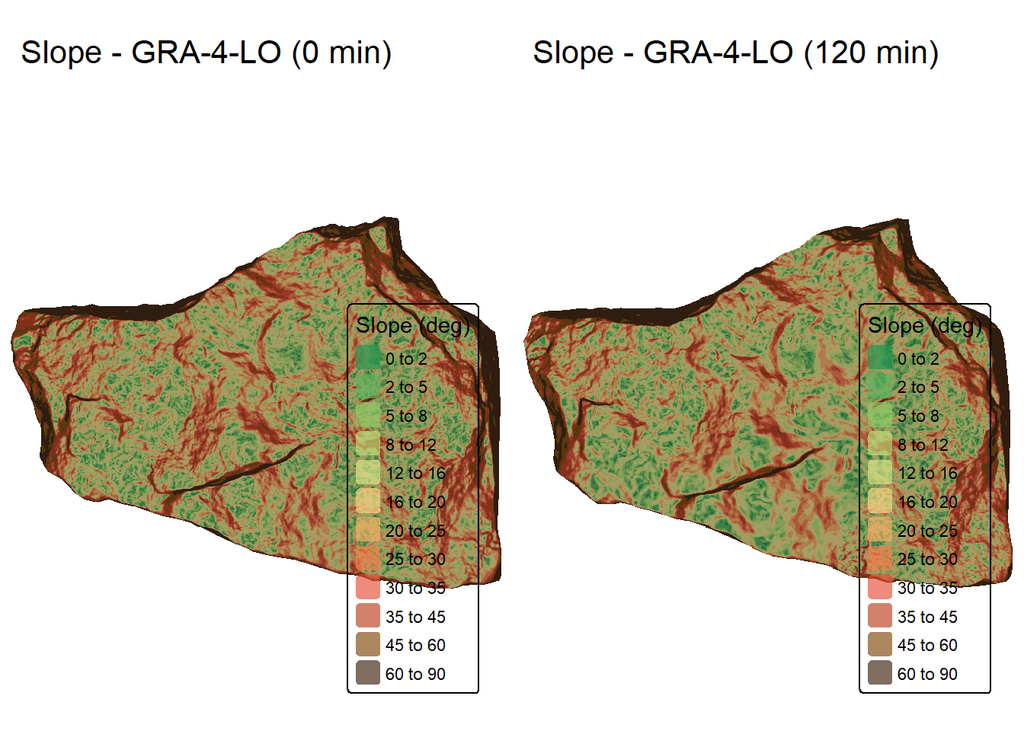

```r
plot_slope_0_120("./DEMs/GRA-4-LO/", "GRA-4-LO")
```

[output not shown]

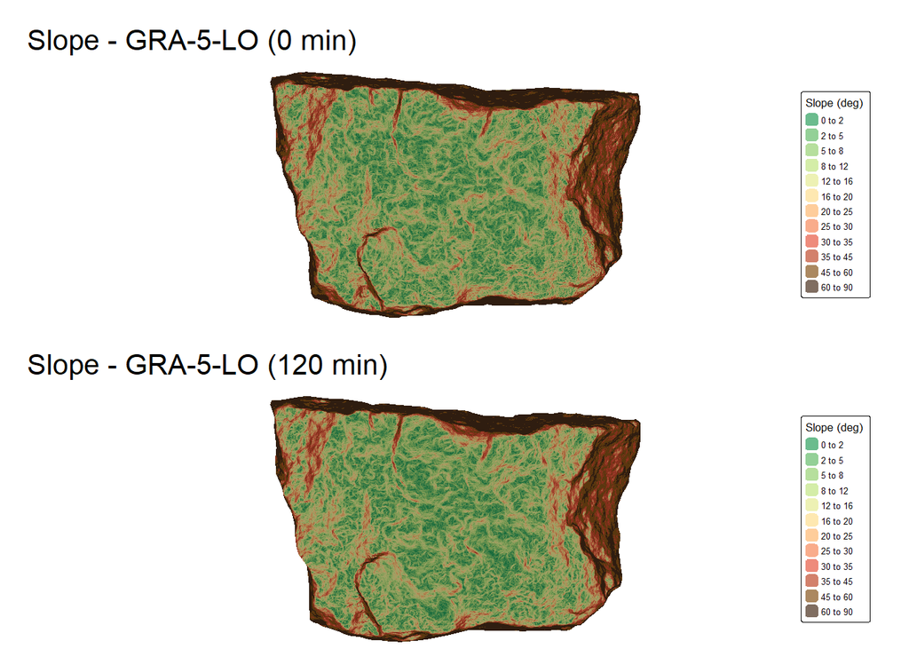

```r
plot_slope_0_120("./DEMs/GRA-5-LO/", "GRA-5-LO")
```

```
## [v3->v4] `tmap_options()`: use raster.max_cells instead of max.raster
```

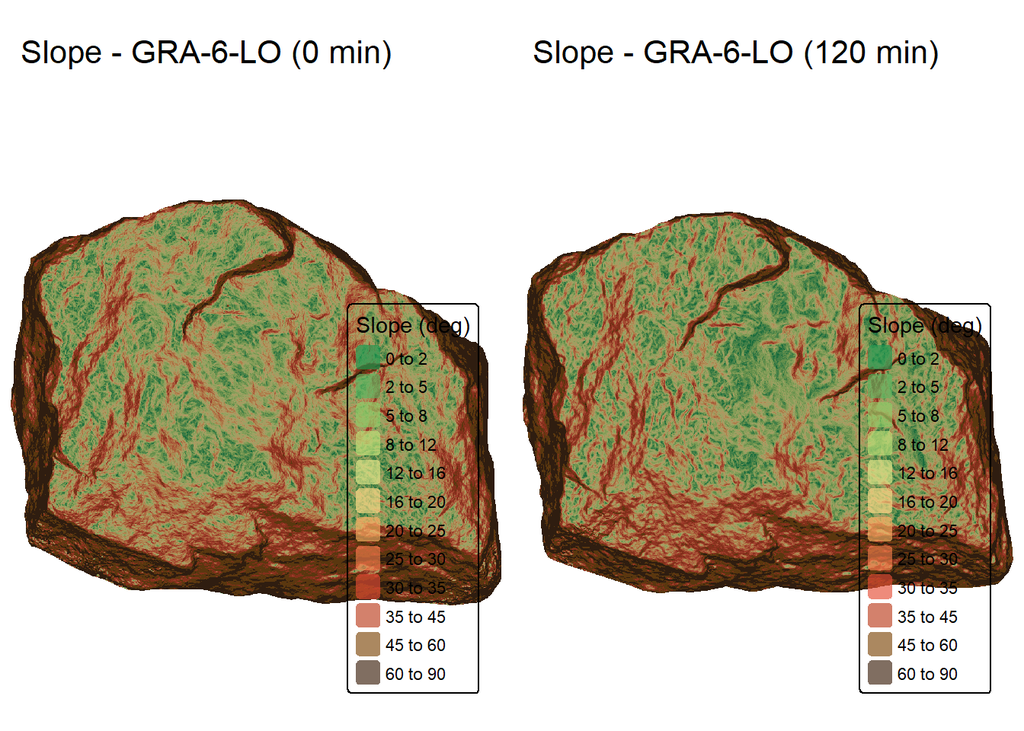

```r
plot_slope_0_120("./DEMs/GRA-6-LO/", "GRA-6-LO")
```

[output not shown]

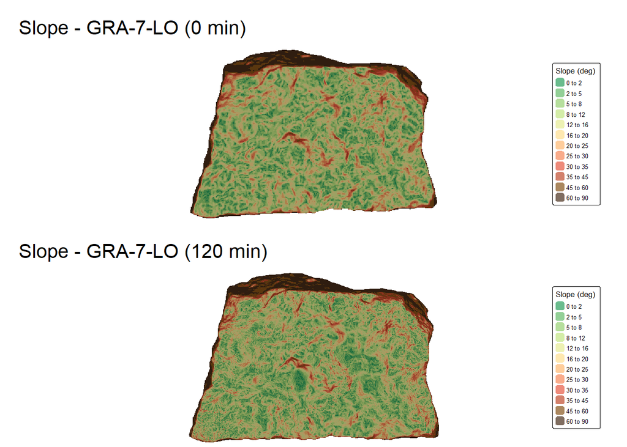

```r
plot_slope_0_120("./DEMs/GRA-7-LO/", "GRA-7-LO")
```

```
## [v3->v4] `tmap_options()`: use raster.max_cells instead of max.raster
```

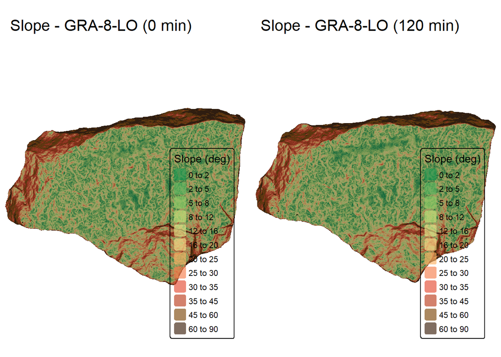

```r
plot_slope_0_120("./DEMs/GRA-8-LO/", "GRA-8-LO")
```

### Data cleaning

In the following code chuck, categorical variables for material and contact area of the active stone are added to the dataset. These variables represent the type of active stone used to grind the surface of the granite artefacts. They play a critical role in the analysis, as they are directly related to the second hypothesis tested in this study.

```r
#Add categories into the data-set
ts_all <- ts_all |>
  mutate(contact_area = case_when(
    run %in% c("GRA-1-LO", "GRA-2-LO", "GRA-5-LO", "GRA-6-LO") ~ "Large",
    run %in% c("GRA-3-LO", "GRA-4-LO", "GRA-7-LO","GRA-8-LO") ~ "Small"
  )) |>
  mutate(material = case_when(
    run %in% c("GRA-1-LO", "GRA-3-LO", "GRA-5-LO", "GRA-7-LO") ~ "Dolerite",
    run %in% c("GRA-2-LO", "GRA-4-LO", "GRA-6-LO","GRA-8-LO") ~ "Quartzite"
  ))

ts_all_df <- data.frame(ts_all)

ts_all_df$contact_area <- factor(ts_all_df$contact_area,
                                 levels = c("Large", "Small"))
ts_all_df$material <- factor(ts_all_df$material,
                                 levels = c("Dolerite", "Quartzite"))
```

### Data analysis

#### Pearson

Next, we visualise the mean slope of each granite sample at each time interval using a scatter plot, with grinding duration as the independent variable, to examine trends in surface modification throughout the experiment. Furthermore, a linear model (ordinary least-square) with a t-test to compute the p-value was fitted to each experimental run to examine the relationship between the mean slope index at each time interval (approxi for grinding duration). Note here that time interval and mean slope surface are treated as continuous variables.

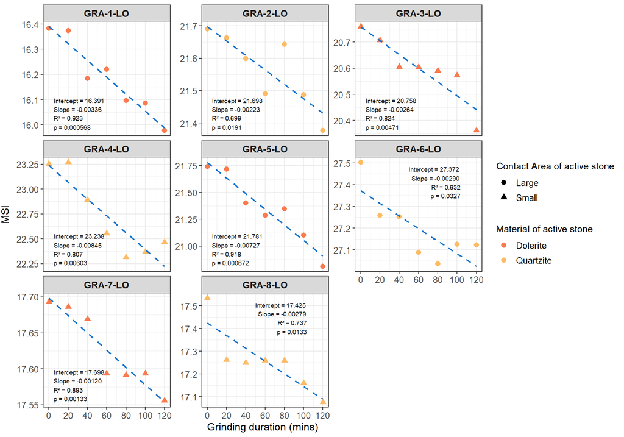

Figure 1: Linear trend per granite sample throughout the experiment

```r
# Fit lm per run and extract stats
ann_run <- ts_all_df %>%
  group_by(run) %>%
  nest() %>%
  mutate(
    fit = map(data, ~ lm(slope_mean ~ grinding_duration, data = .x)),
    intercept = map_dbl(fit, ~ coef(.x)[1]),
    slope     = map_dbl(fit, ~ coef(.x)[2]),
    r2        = map_dbl(fit, ~ summary(.x)$r.squared),
    p_value   = map_dbl(fit, ~ summary(.x)$coefficients["grinding_duration", "Pr(>|t|)"])
  ) %>%
  mutate(
    label = sprintf("Intercept = %.3f\nSlope = %.5f\nR² = %.3f\np = %.3g",
                    intercept, slope, r2, p_value)
  ) %>%
  ungroup()

ann_run <- ann_run %>%
  mutate(
    x = case_when(
      run %in% c("GRA-6-LO", "GRA-8-LO") ~ 105,  # move further right
      TRUE ~ 5                                # left group stays near left
    ),
    y = case_when(
      run %in% c("GRA-6-LO", "GRA-8-LO") ~ Inf,  # top for those two
      TRUE ~ -Inf                          # bottom for the rest
    ),
    hjust = case_when(
      run %in% c("GRA-6-LO", "GRA-8-LO") ~ 1.05, # push text slightly inward from right
      TRUE ~ 0
    ),
    vjust = case_when(
      run %in% c("GRA-6-LO", "GRA-8-LO") ~ 1.3,  # push downward from top edge
      TRUE ~ -0.2                              # push further downward at bottom
    )
  )

# Plot all runs using scatter plot.
ggplot(ts_all_df, aes(grinding_duration, slope_mean, colour = material, shape = contact_area)) +
  geom_point(size = 2.5) +
  theme(legend.position = "none") +
  facet_wrap(~ run, nrow = 3, scales = "free_y") +
  geom_smooth(method = "lm", colour = "dodgerblue3", se = FALSE, linetype = "dashed",
              size = 0.8) +
  scale_colour_manual(values = c(
    "Dolerite"  = "#f97b4f",
    "Quartzite" = "#fcbc66"
  )) +
  labs(x = "Grinding duration (mins)",
       y = "MSI",
       colour = "Material of active stone") +
  scale_shape_discrete(name = "Contact Area of active stone") +
  theme_bw() +
  theme(
    strip.text = element_text(size = 11, face = "bold"),
    axis.title = element_text(size = 12),
    axis.text  = element_text(size = 10),
    legend.title = element_text(size = 11),
    legend.text = element_text(size = 10),
    plot.title = element_text(size = 14, face = "bold"),
    axis.title.y = element_text(vjust = 3)) +
  scale_x_continuous(breaks = seq(0,120, 20)) +
  geom_text(
    data = ann_run,
    aes(x = x, y = y, label = label, hjust = hjust, vjust = vjust),
    inherit.aes = FALSE,
    size = 2.5
  )
```

#### Linear mixed model

As shown in Figure 1, there appears to be a negative relationship between grinding duration and surface morphology, with the mean slope index (MSI) decreasing as grinding duration increases. To further investigate this relationship and assess the influence of active-stone contact area and active-stone material on surface modification, a linear mixed-effects regression model was fitted to the full dataset.

Figure 1 also illustrates that individual experimental runs exhibit different intercepts and slopes in their fitted linear relationships. These differences are treated as random effects, representing run-to-run variability that is not of primary inferential interest but must be accounted for to avoid biased estimates and inflated Type I or Type II error rates. A mixed-effects regression model is therefore appropriate, as it explicitly models between-run variability through random effects while estimating population-level relationships for the fixed effects.

The primary focus of this study lies on the fixed effects of grinding duration, active-stone contact area, and active-stone material and how they effect the variable of mean surface index (MSI). The model was fitted using the following procedure.

First, model assumption were evaluated - whether random effects (i.e., intercepts and slopes) are correlated (see [Thulin, 2026](https://modernstatisticswithr.com/regression.html#mixedmodels)).

```r
coef_df <- ts_all_df %>%
  split(.$run) %>%
  map(~ lm(slope_mean ~ grinding_duration, data = .x)) %>%
  map(coef) %>%
  do.call(rbind, .) %>%
  as.data.frame()

names(coef_df) <- c("Intercept","Slope")

coef_df
```

```
##          Intercept        Slope
## GRA-1-LO  16.39061 -0.003363061
## GRA-2-LO  21.69776 -0.002226512
## GRA-3-LO  20.75832 -0.002637994
## GRA-4-LO  23.23774 -0.008447896
## GRA-5-LO  21.78102 -0.007274586
## GRA-6-LO  27.37208 -0.002899215
## GRA-7-LO  17.69827 -0.001203523
## GRA-8-LO  17.42483 -0.002794786
```

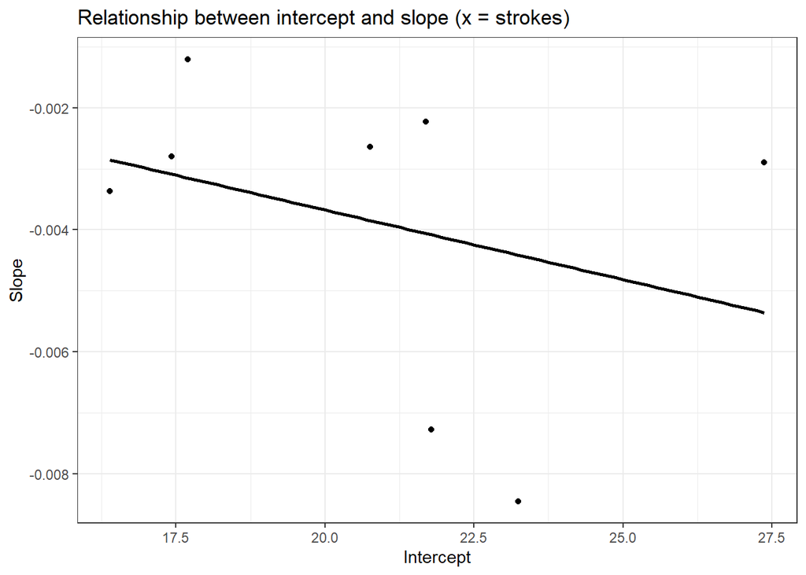

```r
ggplot(coef_df, aes(Intercept, Slope, colour = row.names(coefficients))) +
  geom_point() +
  scale_color_discrete(name = "Granite sample") +
  geom_smooth(method = "lm", colour = "black", se = FALSE) +
  theme(axis.title.y = element_text(vjust = 3),
        legend.title = element_text(size = 8, face = 2),
        legend.text  = element_text(size = 6)) +
  theme_bw() +
  labs(title = "Relationship between intercept and slope (x = strokes)",
       fill = "run")
```

```r
cor.test(coef_df$Intercept, coef_df$Slope)
```

```
##
##  Pearson's product-moment correlation
##
## data:  coef_df$Intercept and coef_df$Slope
## t = -0.82881, df = 6, p-value = 0.4389
## alternative hypothesis: true correlation is not equal to 0
## 95 percent confidence interval:
##  -0.8363007  0.4962408
## sample estimates:
##        cor
## -0.3205107
```

There is no correlation between the two random effects. It is therefore appropriate to fit the model using the following code chunk (following [Thulin,2026](https://modernstatisticswithr.com/regression.html#mixedmodels)):

```r
# Mixed linear model: random intercept + random slope
options(contrasts = c("contr.sum", "contr.poly"))
m_ri <- lmer(slope_mean ~ grinding_duration*contact_area*material + (1 | run)+ (0 + grinding_duration| run), data = ts_all_df)
confint(m_ri)
```

```
## Computing profile confidence intervals ...
```

```
##                                                   2.5 %        97.5 %
## .sig01                                     1.6578153461  4.5385486157
## .sig02                                     0.0005982262  0.0029947136
## .sigma                                     0.0799524715  0.1244605670
## (Intercept)                               18.8095982880 22.7805589366
## grinding_duration                         -0.0052267433 -0.0024851503
## contact_area1                             -0.9701921522  3.0007684964
## material1                                 -3.6235023608  0.3474582878
## grinding_duration:contact_area1           -0.0014556933  0.0012858997
## grinding_duration:material1               -0.0011346409  0.0016069521
## contact_area1:material1                   -3.0720093973  0.8989512513
## grinding_duration:contact_area1:material1 -0.0029849322 -0.0002433392
```

```r
summary(m_ri)
```

```
## Linear mixed model fit by REML. t-tests use Satterthwaite's method [
## lmerModLmerTest]
## Formula: slope_mean ~ grinding_duration * contact_area * material + (1 |
##     run) + (0 + grinding_duration | run)
##    Data: ts_all_df
##
## REML criterion at convergence: 20.3
##
## Scaled residuals:
##      Min       1Q   Median       3Q      Max
## -2.51071 -0.45461  0.05005  0.37668  2.13347
##
## Random effects:
##  Groups   Name              Variance  Std.Dev.
##  run      (Intercept)       7.451e+00 2.729572
##  run.1    grinding_duration 5.178e-06 0.002275
##  Residual                   1.037e-02 0.101835
## Number of obs: 56, groups:  run, 8
##
## Fixed effects:
##                                             Estimate Std. Error         df
## (Intercept)                               20.7950787  0.9653611  8.3393670
## grinding_duration                         -0.0038559  0.0008735  4.0024258
## contact_area1                              1.0152882  0.9653611  8.3393670
## material1                                 -1.6380220  0.9653611  8.3393670
## grinding_duration:contact_area1           -0.0000849  0.0008735  4.0024258
## grinding_duration:material1                0.0002362  0.0008735  4.0024258
## contact_area1:material1                   -1.0865290  0.9653611  8.3393670
## grinding_duration:contact_area1:material1 -0.0016141  0.0008735  4.0024258
##                                           t value Pr(>|t|)
## (Intercept)                                21.541 1.32e-08 ***
## grinding_duration                          -4.415   0.0115 *
## contact_area1                               1.052   0.3224
## material1                                  -1.697   0.1266
## grinding_duration:contact_area1            -0.097   0.9272
## grinding_duration:material1                 0.270   0.8002
## contact_area1:material1                    -1.126   0.2917
## grinding_duration:contact_area1:material1  -1.848   0.1383
## ---
## Signif. codes:  0 '***' 0.001 '**' 0.01 '*' 0.05 '.' 0.1 ' ' 1
##
## Correlation of Fixed Effects:
##             (Intr) grndn_ cntc_1 matrl1 gr_:_1 grn_:1 cn_1:1
## grndng_drtn -0.008
## contact_ar1  0.000  0.000
## material1    0.000  0.000  0.000
## grndng_d:_1  0.000  0.000 -0.008  0.000
## grndng_dr:1  0.000  0.000  0.000 -0.008  0.000
## cntct_r1:m1  0.000  0.000  0.000  0.000  0.000  0.000
## grndn_:_1:1  0.000  0.000  0.000  0.000  0.000  0.000 -0.008
## optimizer (nloptwrap) convergence code: 0 (OK)
## Model failed to converge with max|grad| = 0.218281 (tol = 0.002, component 1)
##   See ?lme4::convergence and ?lme4::troubleshooting.
```

The model is then simplified to a more parsimonious form by removing the material variable, as it is not central to the primary hypothesis ([Bates, 2015](https://doi.org/10.48550/arxiv.1506.04967)). The following code is used to fit the reduced linear mixed-effects model.

```r
# Now we reduce the model
m1 <- lmer(slope_mean ~ grinding_duration*contact_area + (1 | run) + (0 +  grinding_duration | run),
           data = ts_all_df)
confint(m1)
```

```
## Computing profile confidence intervals ...
```

```
##                                        2.5 %       97.5 %
## .sig01                           2.109178174  5.772077626
## .sig02                           0.001253825  0.004202116
## .sigma                           0.079868114  0.124135862
## (Intercept)                     18.269947352 23.320210308
## grinding_duration               -0.005738058 -0.001973835
## contact_area1                   -1.509843088  3.540419867
## grinding_duration:contact_area1 -0.001967008  0.001797215
```

```r
summary(m1)
```

```
## Linear mixed model fit by REML. t-tests use Satterthwaite's method [
## lmerModLmerTest]
## Formula: slope_mean ~ grinding_duration * contact_area + (1 | run) + (0 +
##     grinding_duration | run)
##    Data: ts_all_df
##
## REML criterion at convergence: 7.4
##
## Scaled residuals:
##      Min       1Q   Median       3Q      Max
## -2.45114 -0.46291 -0.03423  0.35788  2.12768
##
## Random effects:
##  Groups   Name              Variance  Std.Dev.
##  run      (Intercept)       7.094e+00 2.663464
##  run.1    grinding_duration 6.634e-06 0.002576
##  Residual                   1.119e-02 0.105782
## Number of obs: 56, groups:  run, 8
##
## Fixed effects:
##                                   Estimate Std. Error         df t value
## (Intercept)                     20.7950787  0.9420213 14.2860311  22.075
## grinding_duration               -0.0038559  0.0009768  6.0087478  -3.948
## contact_area1                    1.0152882  0.9420213 14.2860311   1.078
## grinding_duration:contact_area1 -0.0000849  0.0009768  6.0087478  -0.087
##                                 Pr(>|t|)
## (Intercept)                     1.92e-12 ***
## grinding_duration                0.00754 **
## contact_area1                    0.29900
## grinding_duration:contact_area1  0.93356
## ---
## Signif. codes:  0 '***' 0.001 '**' 0.01 '*' 0.05 '.' 0.1 ' ' 1
##
## Correlation of Fixed Effects:
##             (Intr) grndn_ cntc_1
## grndng_drtn -0.008
## contact_ar1  0.000  0.000
## grndng_d:_1  0.000  0.000 -0.008
## optimizer (nloptwrap) convergence code: 0 (OK)
## Model failed to converge with max|grad| = 0.4496 (tol = 0.002, component 1)
##   See ?lme4::convergence and ?lme4::troubleshooting.
```

We can now compare the two models using a likelihood ratio test.

```r
anova(m1,m_ri)
```

```
## refitting model(s) with ML (instead of REML)
```

```
## Data: ts_all_df
## Models:
## m1: slope_mean ~ grinding_duration * contact_area + (1 | run) + (0 + grinding_duration | run)
## m_ri: slope_mean ~ grinding_duration * contact_area * material + (1 | run) + (0 + grinding_duration | run)
##      npar      AIC    BIC  logLik -2*log(L)  Chisq Df Pr(>Chisq)
## m1      7 -0.60574 13.572  7.3029   -14.606
## m_ri   11 -1.39701 20.882 11.6985   -23.397 8.7913  4    0.06653 .
## ---
## Signif. codes:  0 '***' 0.001 '**' 0.01 '*' 0.05 '.' 0.1 ' ' 1
```

### Model diagnostics.

The diagnostic process for linear mixed-effects models involves evaluating key assumptions to ensure model validity and reliability. These include: - homogeneity of variance, - assessing the normality of residuals, - assessing the normality of random effects. (following [Meteyard & Davis, 2020](https://doi.org/10.1016/j.jml.2020.104092))

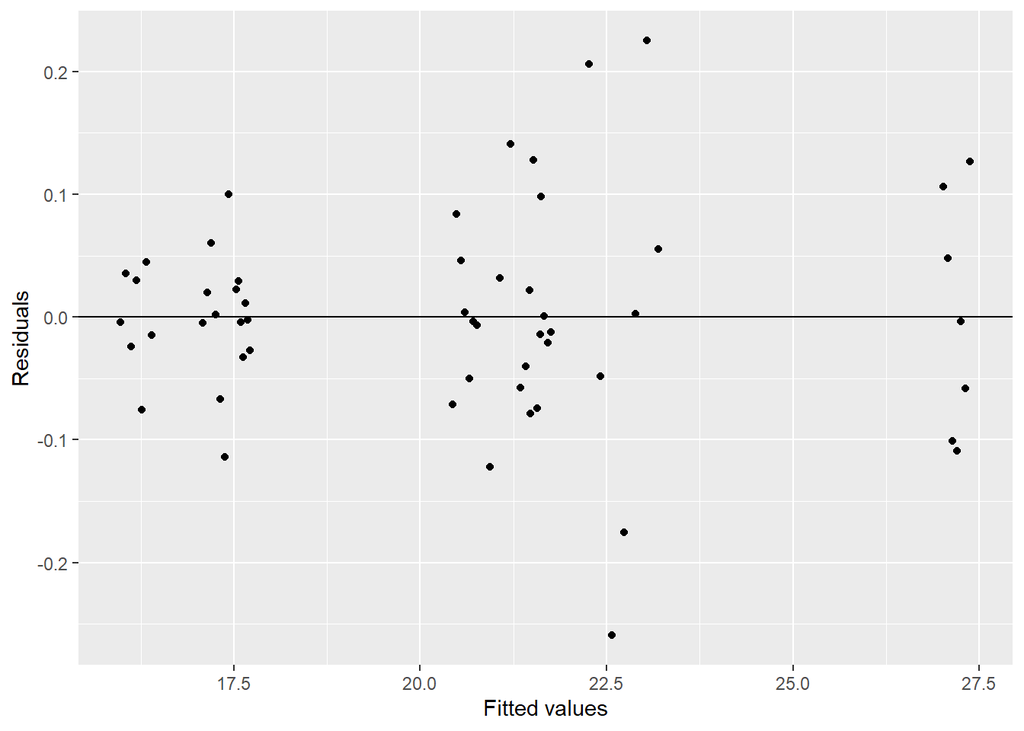

```r
### Diagnostics for m1
### homogeneity of variance
fm4 <- fortify.merMod(m1)

ggplot(fm4, aes(.fitted, .resid)) +
  geom_point() +
  geom_hline(yintercept = 0) +
  xlab("Fitted values") + ylab("Residuals")
```

Inspection of residuals plotted against fitted values indicated no clear systematic pattern, with residuals distributed approximately symmetrically around zero across the range of fitted values. The spread of residuals appeared relatively constant, providing no strong evidence of heteroscedasticity. While some clustering of residuals was observed at specific fitted value ranges, this is likely attributable to the grouped structure of the data inherent in the linear mixed-effects model and does not indicate model misspecification (i.e., no curve or fan shape seen). A small number of residuals showed slightly larger deviations; however, these were not extreme and did not substantially influence the overall pattern. Taken together, these observations suggest that the assumptions of homoscedasticity and adequate model fit were reasonably satisfied.

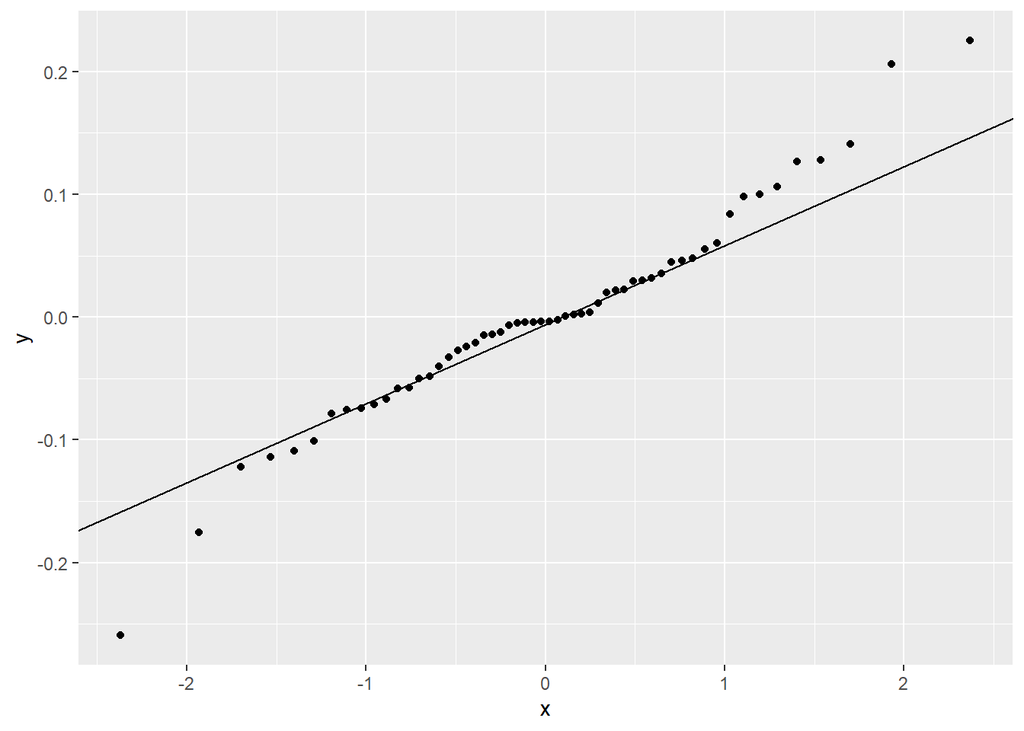

```r
# assessing the normality of  residuals,

ggplot(fm4, aes(sample = .resid)) +
  geom_qq() + geom_qq_line()
```

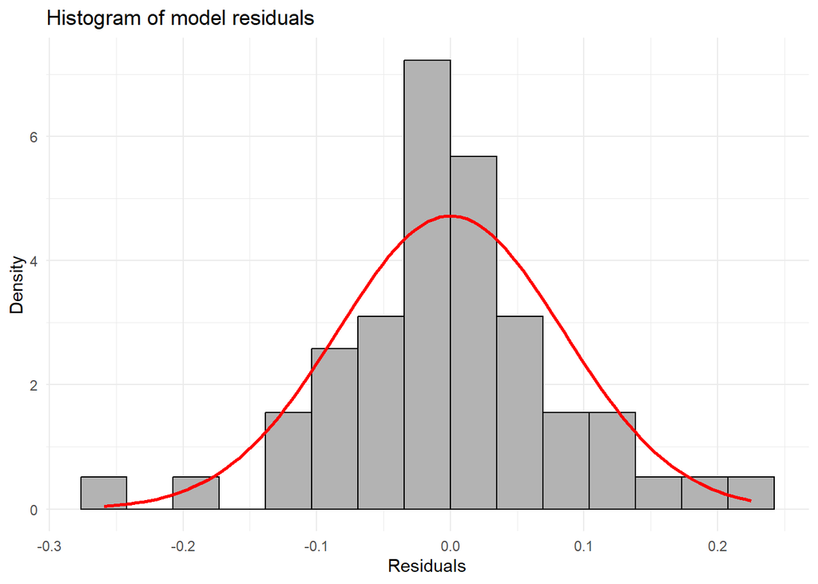

```r
rs_m1 <- data.frame(resid_m1 = fm4$.resid)
ggplot(rs_m1, aes(x = resid_m1)) +
  geom_histogram(aes(y = after_stat(density)),
                 bins = 15,
                 fill = "grey70",
                 color = "black") +
  stat_function(fun = dnorm,
                args = list(mean = mean(rs_m1$resid_m1),
                            sd   = sd(rs_m1$resid_m1)),
                color = "red", linewidth = 1) +
  labs(title = "Histogram of model residuals",
       x = "Residuals", y = "Density") +
  theme_minimal()
```

Assessment of residual normality was conducted using both a Q–Q plot and a histogram with a fitted density curve. Visual inspection of the Q–Q plot indicated that residuals closely followed the expected normal distribution, with points aligning well along the reference line across the central range. Minor deviations were observed at the extreme tails, where a small number of points fell slightly away from the line; however, these deviations were limited and not indicative of substantial non-normality. This pattern was supported by the histogram of residuals, which displayed an approximately symmetric, bell-shaped distribution centred around zero. Although slight skewness and a small number of extreme values were present, the overall distribution remained consistent with the assumption of normality. Taken together, these diagnostics suggest that the assumption of normally distributed residuals was reasonably satisfied.

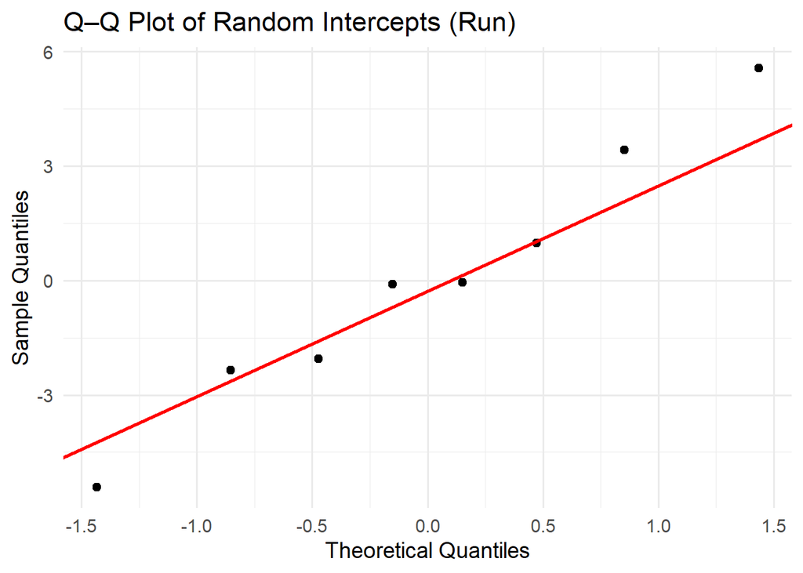

```r
# assessing the normality of random effects (intercept)
ggplot(ranef(m1)$run, aes(sample = `(Intercept)`)) +
  stat_qq(size = 2, colour = "black") +
  stat_qq_line(colour = "red", linewidth = 1) +
  labs(
    title = "Q–Q Plot of Random Intercepts (Run)",
    x = "Theoretical Quantiles",
    y = "Sample Quantiles"
  ) +
  theme_minimal(base_size = 14)
```

The normality of the random **intercepts** was assessed using a Q–Q plot. Visual inspection indicated that the points broadly followed the reference line, suggesting that the distribution of random intercepts was approximately normal. Some deviation was observed at the extreme quantiles, particularly at the upper end, where a small number of points fell above the line. However, given the limited number of grouping levels (runs), such deviations are expected and do not necessarily indicate a violation of model assumptions. Overall, there was no evidence of substantial non-normality in the random intercepts.

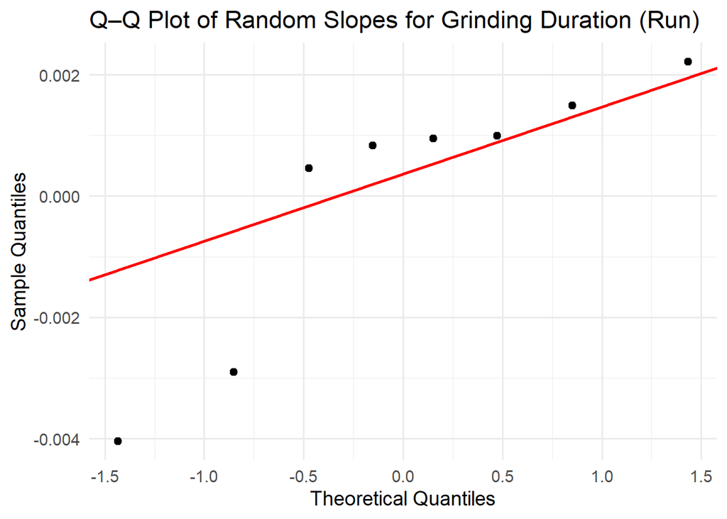

```r
# assessing the normality of random effects (regression slope)
ggplot(ranef(m1)$run, aes(sample = grinding_duration)) +
  stat_qq(size = 2, colour = "black") +
  stat_qq_line(colour = "red", linewidth = 1) +
  labs(
    title = "Q–Q Plot of Random Slopes for Grinding Duration (Run)",
    x = "Theoretical Quantiles",
    y = "Sample Quantiles"
  ) +
  theme_minimal(base_size = 14)
```

Reference:

- Thulin, M. (2026). Modern Statistics with R: From Wrangling and Exploring Data to Inference and Predictive Modelling (Second edition). Chapman & Hall. https://doi.org/10.1201/9781003401339
- Bates, D., Kliegl, R., Vasishth, S., & Baayen, H. (2015). Parsimonious Mixed Models. https://doi.org/10.48550/arxiv.1506.04967
- Meteyard, L., & Davies, R. A. I. (2020). Best practice guidance for linear mixed-effects models in psychological science. Journal of Memory and Language, 112, Article 104092. https://doi.org/10.1016/j.jml.2020.104092